# Reproducible Research Week 2 Project

## Loading and preprocessing the data

### Unzip archive and read data

```r
library(ggplot2)
unzip("activity.zip")
baseData <- read.csv("activity.csv")
```

### Summarize Data

```r
head(baseData)
```

```
##   steps       date interval
## 1    NA 2012-10-01        0
## 2    NA 2012-10-01        5
## 3    NA 2012-10-01       10
## 4    NA 2012-10-01       15
## 5    NA 2012-10-01       20
## 6    NA 2012-10-01       25
```

```r
dim(baseData)
```

```
## [1] 17568     3
```

```r
summary(baseData)
```

```
##      steps                date          interval
##  Min.   :  0.00   2012-10-01:  288   Min.   :   0.0
##  1st Qu.:  0.00   2012-10-02:  288   1st Qu.: 588.8
##  Median :  0.00   2012-10-03:  288   Median :1177.5
##  Mean   : 37.38   2012-10-04:  288   Mean   :1177.5
##  3rd Qu.: 12.00   2012-10-05:  288   3rd Qu.:1766.2
##  Max.   :806.00   2012-10-06:  288   Max.   :2355.0
##  NA's   :2304     (Other)   :15840
```

### NA and Date String to Date Class modification

```r
baseData$date <- as.Date(as.character(baseData$date))
baseDataNA <- is.na(baseData$steps)
cleanBase <- baseData[!baseDataNA,]
```

## What is mean total number of steps taken per day?

### 1. Calculate the total number of steps taken per day

```r
SummedDataByDay <- aggregate(baseData$steps, by=list(baseData$date), sum)
names(SummedDataByDay)[1] ="date"
names(SummedDataByDay)[2] ="totalsteps"
```

### 2. Make a histogram of the total number of steps taken each day

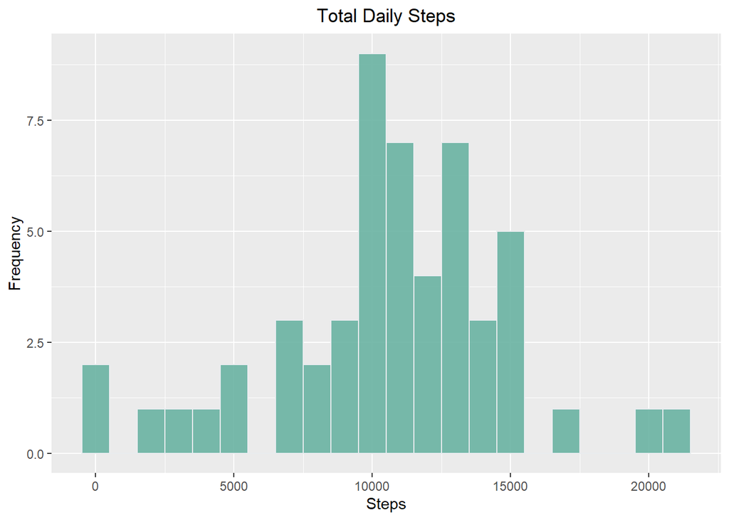

```r
ggplot(SummedDataByDay, aes(x = totalsteps)) +
  geom_histogram(binwidth=1000,fill="#69b3a2", color="#e9ecef", alpha=0.9) +
  labs(title = "Total Daily Steps", x = "Steps", y = "Frequency")+
  theme(plot.title = element_text(hjust = 0.5))
```

### 3. Calculate and report the mean and median of the total number of steps taken per day

```r
m1 = mean(SummedDataByDay$totalsteps,na.rm=TRUE)

sprintf("Mean steps taken per day is: %s", m1)
```

```
## [1] "Mean steps taken per day is: 10766.1886792453"
```

```r
m2 = median(SummedDataByDay$totalsteps,na.rm=TRUE)

sprintf("Median steps taken per day is: %s", m2)
```

```
## [1] "Median steps taken per day is: 10765"
```

## What is the average daily activity pattern?

### 1. Make a time series plot of the 5-minute interval (x-axis) and the average number of steps taken, averaged across all days (y-axis)

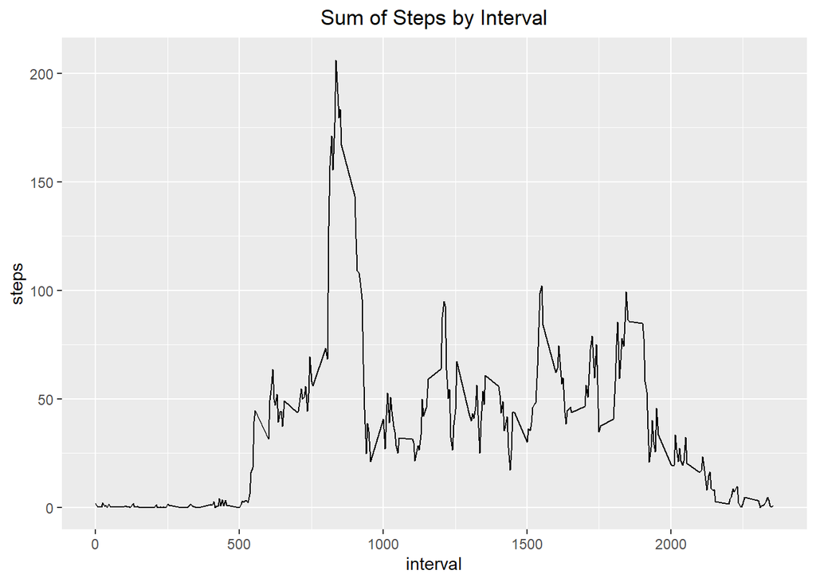

```r
nonNASubset <- baseData[!baseDataNA,]
MeanDataByInterval <- aggregate(nonNASubset$steps, by=list(nonNASubset$interval), mean)
# set the column names
names(MeanDataByInterval)[1] ="interval"
names(MeanDataByInterval)[2] ="steps"

ggplot(MeanDataByInterval, aes(x = interval, y=steps)) +
  labs(title = "Sum of Steps by Interval", x = "interval", y = "steps")+
  geom_line() +
  theme(plot.title = element_text(hjust = 0.5))
```

### 2. Which 5-minute interval, on average across all the days in the dataset, contains the maximum number of steps?

```r
maxInterval <- MeanDataByInterval[which.max(MeanDataByInterval$steps),]
m3 = maxInterval[1]
m4 = maxInterval[2]

sprintf("Interval with maximum number of stpes: %s", m3)
```

```
## [1] "Interval with maximum number of stpes: 835"
```

```r
sprintf("This interval has: %s steps", m4)
```

```
## [1] "This interval has: 206.169811320755 steps"
```

## Imputing missing values

### 1. Calculate and report the total number of missing values in the dataset (i.e. the total number of rows with NAs)

```r
missingVals <- sum(baseDataNA)
sprintf("Total missing values: %s", missingVals)
```

```
## [1] "Total missing values: 2304"
```

### 2/3. Devise a strategy for filling in all of the missing values in the dataset.Create a new dataset that is equal to the original dataset but with the missing data filled in.

Using Mean to inpute missing values

```r
baseData2 <- baseData

NABase2 <- baseData2[is.na(baseData2$steps),]
cleanBase2 <- baseData2[!is.na(baseData2$steps),]

MeanData2ByInterval <- aggregate(cleanBase2$steps, by=list(cleanBase2$interval), sum)
names(MeanData2ByInterval)[1] ="interval"
names(MeanData2ByInterval)[2] ="steps"

baseData2 <- baseData
missingData <- is.na(baseData2$steps)
meanVals <- tapply(cleanBase$steps, cleanBase$interval, mean, na.rm=TRUE, simplify=TRUE)
baseData2$steps[missingData] <- meanVals[as.character(baseData2$interval[missingData])]
```

### 4a. Make a histogram of the total number of steps taken each day and Calculate and report the mean and median total number of steps taken per day.

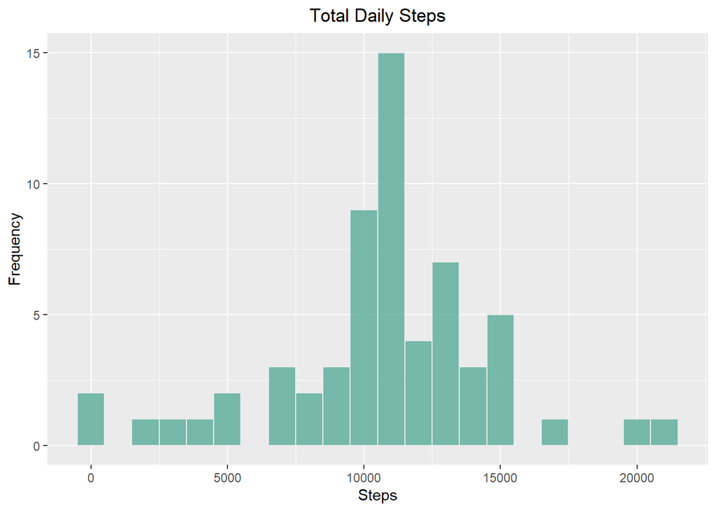

```r
FullSummedDataByDay <- aggregate(baseData2$steps, by=list(baseData2$date), sum)

names(FullSummedDataByDay)[1] ="date"
names(FullSummedDataByDay)[2] ="totalsteps"

ggplot(FullSummedDataByDay, aes(x = totalsteps)) +
  geom_histogram(binwidth=1000,fill="#69b3a2", color="#e9ecef", alpha=0.9) +
  labs(title = "Total Daily Steps", x = "Steps", y = "Frequency")+
    theme(plot.title = element_text(hjust = 0.5))
```

```r
m5 = mean(FullSummedDataByDay$totalsteps)

sprintf("Mean steps taken per day is: %s", m5)
```

```
## [1] "Mean steps taken per day is: 10766.1886792453"
```

```r
m6 = median(FullSummedDataByDay$totalsteps)

sprintf("Median steps taken per day is: %s", m6)
```

```
## [1] "Median steps taken per day is: 10766.1886792453"
```

## Are there differences in activity patterns between weekdays and weekends?

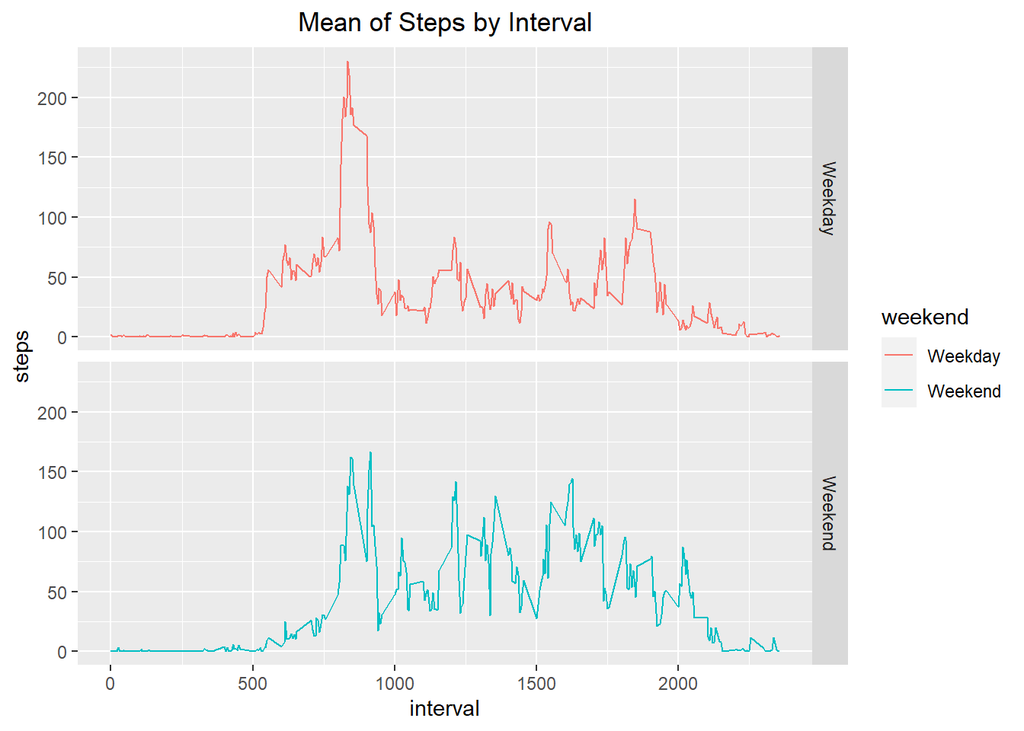

```r
baseData2$weekday <- weekdays(baseData2$date)
baseData2$weekend <- ifelse (baseData2$weekday == "Saturday" | baseData2$weekday == "Sunday", "Weekend", "Weekday")

MeanDataWeekendWeekday <- aggregate(baseData2$steps, by=list(baseData2$weekend, baseData2$interval), mean)
names(MeanDataWeekendWeekday)[1] ="weekend"
names(MeanDataWeekendWeekday)[2] ="interval"
names(MeanDataWeekendWeekday)[3] ="steps"

ggplot(MeanDataWeekendWeekday, aes(x = interval, y=steps, color=weekend)) +
  geom_line() +
  facet_grid(weekend ~ .) +
  labs(title = "Mean of Steps by Interval", x = "interval", y = "steps")+
    theme(plot.title = element_text(hjust = 0.5))
```

There seems to be variation in the beginning of the day during weekdays, likely due to workplace activities. There seems to be an overall slightly larger incidence of steps during the weekends.